# Lab3DecisionTreeBUAN

2024-11-10

#1Import the data2, and partition the data into training (60%) and validation (40%) sets3. Choose your own seed:

library(rpart) library(rpart.plot) library(forecast) library(caret) library(lattice) library(ggplot2)

```r
toyota <- read.csv("/Users/annatran/Downloads/ToyotaCorolla.csv", header = TRUE)
head(toyota)
```

```
##   Id                                             Model Price Age_08_04
## 1  1     TOYOTA Corolla 2.0 D4D HATCHB TERRA 2/3-Doors 13500        23
## 2  2     TOYOTA Corolla 2.0 D4D HATCHB TERRA 2/3-Doors 13750        23
## 3  3 \xa0TOYOTA Corolla 2.0 D4D HATCHB TERRA 2/3-Doors 13950        24
## 4  4     TOYOTA Corolla 2.0 D4D HATCHB TERRA 2/3-Doors 14950        26
## 5  5       TOYOTA Corolla 2.0 D4D HATCHB SOL 2/3-Doors 13750        30
## 6  6       TOYOTA Corolla 2.0 D4D HATCHB SOL 2/3-Doors 12950        32
##   Mfg_Month Mfg_Year    KM Fuel_Type HP Met_Color  Color Automatic   CC Doors
## 1        10     2002 46986    Diesel 90         1   Blue         0 2000     3
## 2        10     2002 72937    Diesel 90         1 Silver         0 2000     3
## 3         9     2002 41711    Diesel 90         1   Blue         0 2000     3
## 4         7     2002 48000    Diesel 90         0  Black         0 2000     3
## 5         3     2002 38500    Diesel 90         0  Black         0 2000     3
## 6         1     2002 61000    Diesel 90         0  White         0 2000     3
##   Cylinders Gears Quarterly_Tax Weight Mfr_Guarantee BOVAG_Guarantee
```

[output cut: 34 more lines]

```r
colnames(toyota) <- make.names(colnames(toyota))
colnames(toyota)
```

```
##  [1] "Id"                "Model"             "Price"
##  [4] "Age_08_04"         "Mfg_Month"         "Mfg_Year"
##  [7] "KM"                "Fuel_Type"         "HP"
## [10] "Met_Color"         "Color"             "Automatic"
## [13] "CC"                "Doors"             "Cylinders"
## [16] "Gears"             "Quarterly_Tax"     "Weight"
## [19] "Mfr_Guarantee"     "BOVAG_Guarantee"   "Guarantee_Period"
## [22] "ABS"               "Airbag_1"          "Airbag_2"
## [25] "Airco"             "Automatic_airco"   "Boardcomputer"
## [28] "CD_Player"         "Central_Lock"      "Powered_Windows"
## [31] "Power_Steering"    "Radio"             "Mistlamps"
## [34] "Sport_Model"       "Backseat_Divider"  "Metallic_Rim"
## [37] "Radio_cassette"    "Parking_Assistant" "Tow_Bar"
```

```r
toyota$Fuel_Type <- as.factor(toyota$Fuel_Type)
```

```r
toyota$Automatic <- as.factor(toyota$Automatic)
toyota$Doors <- as.factor(toyota$Doors)
```

```r
toyota$Mfg_Guarantee <- as.factor(toyota$Mfr_Guarantee)
toyota$Airco <- as.factor(toyota$Airco)
toyota$Automatic_airco <- as.factor(toyota$Automatic_airco)
toyota$CD_Player <- as.factor(toyota$CD_Player)
toyota$Powered_Windows <- as.factor(toyota$Powered_Windows)
toyota$Sport_Model <- as.factor(toyota$Sport_Model)
toyota$Tow_Bar <- as.factor(toyota$Tow_Bar)
```

```r
library(caret)
set.seed(666)
```

```r
index <- createDataPartition(toyota$Price, p = 0.6, list = FALSE)
```

```r
train_df <- toyota[index, ]
valid_df <- toyota[-index, ]
```

```r
nrow(train_df)
```

```
## [1] 863
```

```r
nrow(valid_df)
```

```
## [1] 573
```

```r
head(train_df)
```

```
##   Id                                             Model Price Age_08_04
## 1  1     TOYOTA Corolla 2.0 D4D HATCHB TERRA 2/3-Doors 13500        23
## 4  4     TOYOTA Corolla 2.0 D4D HATCHB TERRA 2/3-Doors 14950        26
## 5  5       TOYOTA Corolla 2.0 D4D HATCHB SOL 2/3-Doors 13750        30
## 6  6       TOYOTA Corolla 2.0 D4D HATCHB SOL 2/3-Doors 12950        32
## 7  7 \xa0TOYOTA Corolla 2.0 D4D 90 3DR TERRA 2/3-Doors 16900        27
## 9  9   \xa0TOYOTA Corolla 1800 T SPORT VVT I 2/3-Doors 21500        27
##   Mfg_Month Mfg_Year    KM Fuel_Type  HP Met_Color Color Automatic   CC Doors
## 1        10     2002 46986    Diesel  90         1  Blue         0 2000     3
## 4         7     2002 48000    Diesel  90         0 Black         0 2000     3
## 5         3     2002 38500    Diesel  90         0 Black         0 2000     3
## 6         1     2002 61000    Diesel  90         0 White         0 2000     3
## 7         6     2002 94612    Diesel  90         1  Grey         0 2000     3
## 9         6     2002 19700    Petrol 192         0   Red         0 1800     3
##   Cylinders Gears Quarterly_Tax Weight Mfr_Guarantee BOVAG_Guarantee
```

[output cut: 34 more lines]

```r
head(valid_df)
```

```
##    Id                                                  Model Price Age_08_04
## 2   2          TOYOTA Corolla 2.0 D4D HATCHB TERRA 2/3-Doors 13750        23
## 3   3      \xa0TOYOTA Corolla 2.0 D4D HATCHB TERRA 2/3-Doors 13950        24
## 8   8          TOYOTA Corolla 2.0 D4D 90 3DR TERRA 2/3-Doors 18600        30
## 10 10        \xa0TOYOTA Corolla 1.9 D HATCHB TERRA 2/3-Doors 12950        23
## 11 11      TOYOTA Corolla 1.8 VVTL-i T-Sport 3-Drs 2/3-Doors 20950        25
## 12 12 TOYOTA Corolla 1.8 16V VVTLI 3DR T SPORT BNS 2/3-Doors 19950        22
##    Mfg_Month Mfg_Year    KM Fuel_Type  HP Met_Color  Color Automatic   CC Doors
## 2         10     2002 72937    Diesel  90         1 Silver         0 2000     3
## 3          9     2002 41711    Diesel  90         1   Blue         0 2000     3
## 8          3     2002 75889    Diesel  90         1   Grey         0 2000     3
## 10        10     2002 71138    Diesel  69         0   Blue         0 1900     3
## 11         8     2002 31461    Petrol 192         0 Silver         0 1800     3
## 12        11     2002 43610    Petrol 192         0    Red         0 1800     3
##    Cylinders Gears Quarterly_Tax Weight Mfr_Guarantee BOVAG_Guarantee
```

[output cut: 34 more lines]

```r
str(train_df)
```

```
## 'data.frame':    863 obs. of  40 variables:
##  $ Id               : int  1 4 5 6 7 9 15 17 20 21 ...
##  $ Model            : chr  "TOYOTA Corolla 2.0 D4D HATCHB TERRA 2/3-Doors" "TOYOTA Corolla 2.0 D4D HATCHB TERRA 2/3-Doors" "TOYOTA Corolla 2.0 D4D HATCHB SOL 2/3-Doors" "TOYOTA Corolla 2.0 D4D HATCHB SOL 2/3-Doors" ...
##  $ Price            : int  13500 14950 13750 12950 16900 21500 22500 22750 16950 15950 ...
##  $ Age_08_04        : int  23 26 30 32 27 27 32 30 30 30 ...
##  $ Mfg_Month        : int  10 7 3 1 6 6 1 3 3 3 ...
##  $ Mfg_Year         : int  2002 2002 2002 2002 2002 2002 2002 2002 2002 2002 ...
##  $ KM               : int  46986 48000 38500 61000 94612 19700 34131 34000 64359 67660 ...
##  $ Fuel_Type        : Factor w/ 3 levels "CNG","Diesel",..: 2 2 2 2 2 3 3 3 3 3 ...
##  $ HP               : int  90 90 90 90 90 192 192 192 110 110 ...
##  $ Met_Color        : int  1 0 0 0 1 0 1 1 1 1 ...
##  $ Color            : chr  "Blue" "Black" "Black" "White" ...
##  $ Automatic        : Factor w/ 2 levels "0","1": 1 1 1 1 1 1 1 1 1 1 ...
##  $ CC               : int  2000 2000 2000 2000 2000 1800 1800 1800 1600 1600 ...
##  $ Doors            : Factor w/ 4 levels "2","3","4","5": 2 2 2 2 2 2 2 2 2 2 ...
```

[output cut: 26 more lines]

```r
str(valid_df)
```

```
## 'data.frame':    573 obs. of  40 variables:
##  $ Id               : int  2 3 8 10 11 12 13 14 16 18 ...
##  $ Model            : chr  "TOYOTA Corolla 2.0 D4D HATCHB TERRA 2/3-Doors" "\xa0TOYOTA Corolla 2.0 D4D HATCHB TERRA 2/3-Doors" "TOYOTA Corolla 2.0 D4D 90 3DR TERRA 2/3-Doors" "\xa0TOYOTA Corolla 1.9 D HATCHB TERRA 2/3-Doors" ...
##  $ Price            : int  13750 13950 18600 12950 20950 19950 19600 21500 22000 17950 ...
##  $ Age_08_04        : int  23 24 30 23 25 22 25 31 28 24 ...
##  $ Mfg_Month        : int  10 9 3 10 8 11 8 2 5 9 ...
##  $ Mfg_Year         : int  2002 2002 2002 2002 2002 2002 2002 2002 2002 2002 ...
##  $ KM               : int  72937 41711 75889 71138 31461 43610 32189 23000 18739 21716 ...
##  $ Fuel_Type        : Factor w/ 3 levels "CNG","Diesel",..: 2 2 2 2 3 3 3 3 3 3 ...
##  $ HP               : int  90 90 90 69 192 192 192 192 192 110 ...
##  $ Met_Color        : int  1 1 1 0 0 0 0 1 0 1 ...
##  $ Color            : chr  "Silver" "Blue" "Grey" "Blue" ...
##  $ Automatic        : Factor w/ 2 levels "0","1": 1 1 1 1 1 1 1 1 1 1 ...
##  $ CC               : int  2000 2000 2000 1900 1800 1800 1800 1800 1800 1600 ...
##  $ Doors            : Factor w/ 4 levels "2","3","4","5": 2 2 2 2 2 2 2 2 2 2 ...
```

[output cut: 26 more lines]

```r
library(rpart)
rt_model <- rpart(Price ~ Age_08_04 + KM + Fuel_Type + HP + Automatic + Doors +
Quarterly_Tax + Mfg_Guarantee + Guarantee_Period + Airco +
Automatic_airco + CD_Player + Powered_Windows + Sport_Model + Tow_Bar,
data = train_df, method = "anova")
```

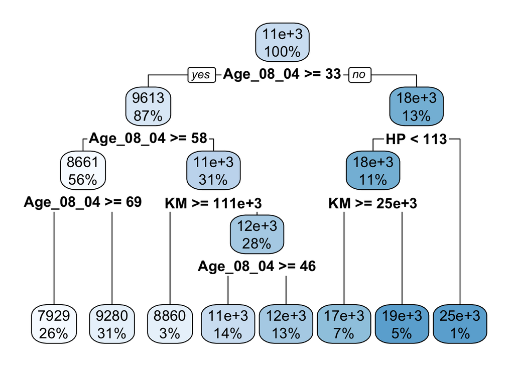

```r
library(rpart.plot)
rpart.plot(rt_model, type = 2, fallen.leaves = TRUE, tweak = 1.2)
```

```r
printcp(rt_model)
```

```
##
## Regression tree:
## rpart(formula = Price ~ Age_08_04 + KM + Fuel_Type + HP + Automatic +
##     Doors + Quarterly_Tax + Mfg_Guarantee + Guarantee_Period +
##     Airco + Automatic_airco + CD_Player + Powered_Windows + Sport_Model +
##     Tow_Bar, data = train_df, method = "anova")
##
## Variables actually used in tree construction:
## [1] Age_08_04 HP        KM
##
## Root node error: 1.1437e+10/863 = 13252491
##
## n= 863
##
##         CP nsplit rel error  xerror     xstd
## 1 0.646162      0   1.00000 1.00306 0.089016
## 2 0.109136      1   0.35384 0.37039 0.034224
## 3 0.049692      2   0.24470 0.26210 0.032199
## 4 0.019297      3   0.19501 0.23876 0.028814
## 5 0.015020      4   0.17571 0.19646 0.018820
## 6 0.011519      5   0.16069 0.18987 0.019192
## 7 0.011267      6   0.14917 0.18551 0.018967
## 8 0.010000      7   0.13791 0.17980 0.018461
```

#3Define the new record

```r
new_record <- data.frame(
Age_08_04 = 77,
KM = 117000,
Fuel_Type = factor("Petrol", levels = levels(train_df$Fuel_Type)),
HP = 110,
Automatic = factor(0, levels = levels(train_df$Automatic)),
Doors = factor(5, levels = levels(train_df$Doors)),
Quarterly_Tax = 100,
Mfg_Guarantee = factor(0, levels = levels(train_df$Mfg_Guarantee)),
Guarantee_Period = 3,
Airco = factor(1, levels = levels(train_df$Airco)),
Automatic_airco = factor(0, levels = levels(train_df$Automatic_Airco)),
CD_Player = factor(0, levels = levels(train_df$CD_Player)),
Powered_Windows = factor(0, levels = levels(train_df$Powered_Windows)),
Sport_Model = factor(0, levels = levels(train_df$Sport_Model)),
Tow_Bar = factor(1, levels = levels(train_df$Tow_Bar)))
```

```r
predicted_price <- predict(rt_model, new_record)
predicted_price
```

```
##        1
## 7929.031
```

#4

```r
toyota$cat_price <- ifelse(toyota$Price <= mean(toyota$Price, na.rm = TRUE), "0", "1")
toyota$cat_price <- as.factor(toyota$cat_price)
```

```r
table(toyota$cat_price)
```

```
##
##   0   1
## 895 541
```

```r
index <- createDataPartition(toyota$cat_price, p = 0.6, list = FALSE)
```

```r
train_df <- toyota[index, ]
valid_df <- toyota[-index, ]
```

```r
ct_model <- rpart(cat_price ~ Age_08_04 + KM + Fuel_Type + HP + Automatic + Doors +
Quarterly_Tax + Mfg_Guarantee + Guarantee_Period + Airco +
Automatic_airco + CD_Player + Powered_Windows + Sport_Model + Tow_Bar,
data = train_df, method = "class",
control = rpart.control(maxdepth = 3))
```

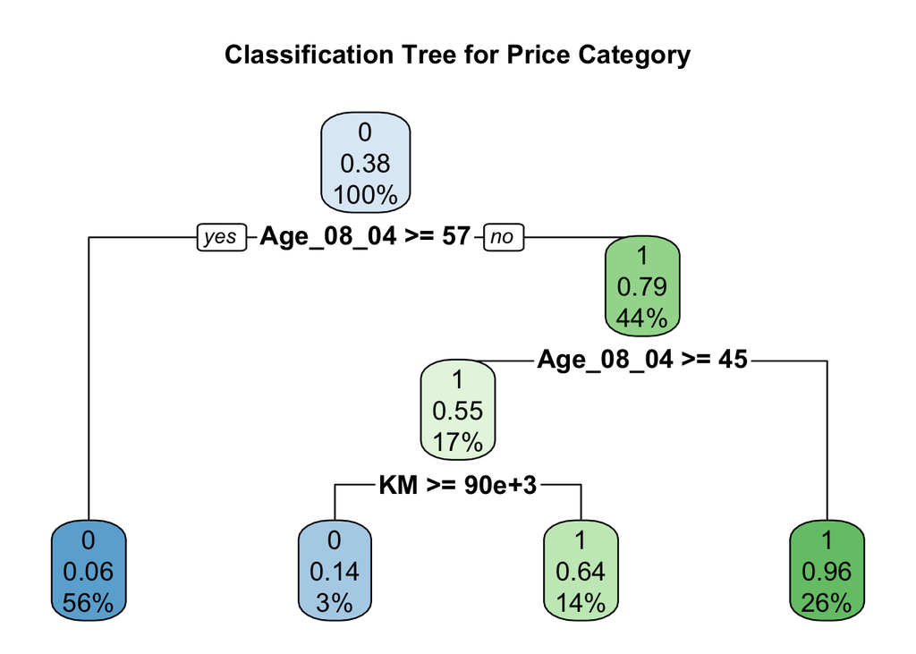

```r
rpart.plot(ct_model, type = 2, fallen.leaves = TRUE, tweak = 1.2, main = "Classification Tree for Price Category")
```

```r
printcp(ct_model)
```

```
##
## Classification tree:
## rpart(formula = cat_price ~ Age_08_04 + KM + Fuel_Type + HP +
##     Automatic + Doors + Quarterly_Tax + Mfg_Guarantee + Guarantee_Period +
##     Airco + Automatic_airco + CD_Player + Powered_Windows + Sport_Model +
##     Tow_Bar, data = train_df, method = "class", control = rpart.control(maxdepth = 3))
##
## Variables actually used in tree construction:
## [1] Age_08_04 KM
##
## Root node error: 325/862 = 0.37703
##
## n= 862
##
##         CP nsplit rel error  xerror     xstd
## 1 0.676923      0   1.00000 1.00000 0.043782
## 2 0.032308      1   0.32308 0.32308 0.029546
## 3 0.010000      3   0.25846 0.28000 0.027759
```

#5

Predictors: The shallow tree, limited to a depth of 3, keeps things simple by focusing on only the most impactful predictors. At this depth, it will likely choose the most influential factors, like Age_08_04, KM, or HP, to make quick, meaningful splits. This makes it straightforward to interpret, showing only the strongest indicators of price upfront. In contrast, the full tree digs deeper, including more variables as it branches out, making it potentially more accurate but also more complicated and possibly prone to overfitting. The top predictors may overlap between the two trees, but the full tree will also pull in additional, less important variables as it goes deeper.

Predictions: The shallow tree’s predictions are more generalized, based on broader categories created by fewer, larger splits. This can make its predictions more robust and adaptable to new data, though perhaps slightly less precise for individual cases. The full tree’s predictions are more tailored, taking into account a greater number of detailed conditions. This can make it more accurate for the specific cases it was trained on, but it also risks being too specific, potentially making it less dependable when applied to new data. If I am running a business, the shallow tree would likely be the better choice. It’s easier to interpret and apply, giving a clear picture of the main drivers of price without getting bogged down by excessive detail. Its simplicity also makes it more adaptable, which means I can be confident it will perform well on new data.